# Lab 2: Introduction to data description

In this lab, you will gain insight into public health by generating simple graphical and numerical summaries of a data set collected by the Centers for Disease Control and Prevention (CDC). As this is a large data set, along the way you’ll also learn the indispensable skills of data processing and subsetting.

## Getting started

The Behavioral Risk Factor Surveillance System (BRFSS) is an annual telephone survey of 350,000 people in the United States. As its name implies, the BRFSS is designed to identify risk factors in the adult population and report emerging health trends. For example, respondents are asked about their diet and weekly physical activity, their HIV/AIDS status, possible tobacco use, and even their level of healthcare coverage. The BRFSS Web site [http://www.cdc.gov/brfss](https://www.cdc.gov/brfss/) contains a complete description of the survey, including the research questions that motivate the study and many interesting results derived from the data.

We will focus on a random sample of 20,000 people from the BRFSS survey conducted in 2000. While there are over 200 variables in this data set, we will work with a small subset.

We begin by loading the data set of 20,000 observations into the R workspace. The data set `cdc` that shows up in your workspace is a *data matrix*, with each row representing a *case* and each column representing a *variable*. R calls this data format a *data frame*.

```r
source("cdc.R")
names(cdc)
```

```
## [1] "genhlth"  "exerany"  "hlthplan" "smoke100" "height"   "weight"   "wtdesire"
## [8] "age"      "gender"
```

```r
head(cdc)
```

```
##     genhlth exerany hlthplan smoke100 height weight wtdesire age gender
## 1      good       0        1        0     70    175      175  77      m
## 2      good       0        1        1     64    125      115  33      f
## 3      good       1        1        1     60    105      105  49      f
## 4      good       1        1        0     66    132      124  42      f
## 5 very good       0        1        0     61    150      130  55      f
## 6 very good       1        1        0     64    114      114  55      f
```

```r
tail(cdc)
```

```
##         genhlth exerany hlthplan smoke100 height weight wtdesire age gender
## 19995      good       0        1        1     69    224      224  73      m
## 19996      good       1        1        0     66    215      140  23      f
## 19997 excellent       0        1        0     73    200      185  35      m
## 19998      poor       0        1        0     65    216      150  57      f
## 19999      good       1        1        0     67    165      165  81      f
## 20000      good       1        1        1     69    170      165  83      m
```

Each one of these variables corresponds to a question that was asked in the survey. For example, for `genhlth`, respondents were asked to evaluate their general health, responding either excellent, very good, good, fair or poor. The `exerany` variable indicates whether the respondent exercised in the past month (1) or did not (0). Likewise, `hlthplan` indicates whether the respondent had some form of health coverage (1) or did not (0). The `smoke100` variable indicates whether the respondent had smoked at least 100 cigarettes in her lifetime. The other variables record the respondent’s `height` in inches, `weight` in pounds as well as their desired weight, `wtdesire`, `age` in years, and `gender`. We can use the following command to see the type of variables (e.g. categorical, discrete):

```r
str(cdc)
```

```
## 'data.frame':    20000 obs. of  9 variables:
##  $ genhlth : Factor w/ 5 levels "excellent","very good",..: 3 3 3 3 2 2 2 2 3 3 ...
##  $ exerany : num  0 0 1 1 0 1 1 0 0 1 ...
##  $ hlthplan: num  1 1 1 1 1 1 1 1 1 1 ...
##  $ smoke100: num  0 1 1 0 0 0 0 0 1 0 ...
##  $ height  : num  70 64 60 66 61 64 71 67 65 70 ...
##  $ weight  : int  175 125 105 132 150 114 194 170 150 180 ...
##  $ wtdesire: int  175 115 105 124 130 114 185 160 130 170 ...
##  $ age     : int  77 33 49 42 55 55 31 45 27 44 ...
##  $ gender  : Factor w/ 2 levels "m","f": 1 2 2 2 2 2 1 1 2 1 ...
```

## Summaries and tables

```r
summary(cdc$weight)
```

```
##    Min. 1st Qu.  Median    Mean 3rd Qu.    Max.
##    68.0   140.0   165.0   169.7   190.0   500.0
```

We can compute the interquartile range `IQR = Q3 - Q1 = 190.0 - 140.0 =50` for the respondents weight. We can compute specific quantiles like this:

```r
Q3 <- quantile(cdc$weight,.75)
Q3
```

```
## 75%
## 190
```

```r
Q1 <- quantile(cdc$weight,.25)
Q1
```

```
## 25%
## 140
```

```r
IQR <- Q3 - Q1
IQR
```

```
## 75%
##  50
```

The special symbol `<-` performs an *assignment*, taking the output of one line of code and saving it into an object in your workspace. This is another important idea that we’ll return to later. R also has built-in functions to compute other summary statistics one by one. For instance, to calculate the mean, median, and variance of `weight`, type

```r
mean(cdc$weight)
```

```
## [1] 169.683
```

```r
median(cdc$weight)
```

```
## [1] 165
```

```r
var(cdc$weight)
```

```
## [1] 1606.484
```

While it makes sense to describe a quantitative variable like `weight` in terms of these statistics, what about categorical data? We would instead consider the sample frequency or relative frequency distribution. The function `table()` does this for you by counting the number of times each kind of response was given. For example, to see the number of people who have smoked 100 cigarettes in their lifetime, type

```r
# Frequency
table(cdc$smoke100)
```

```
##
##     0     1
## 10559  9441
```

```r
# Relative frequency
table(cdc$smoke100)/20000
```

```
##
##       0       1
## 0.52795 0.47205
```

For plotting we will use the package `ggplot2` which is a plotting system for R based on the grammar of graphics. It takes the good parts of base and lattice graphics and provides a powerful model that makes it easy to produce complex multi-layered graphics. To generate a barplot of people who have smoked 100 cigarettes in their lifetime use,

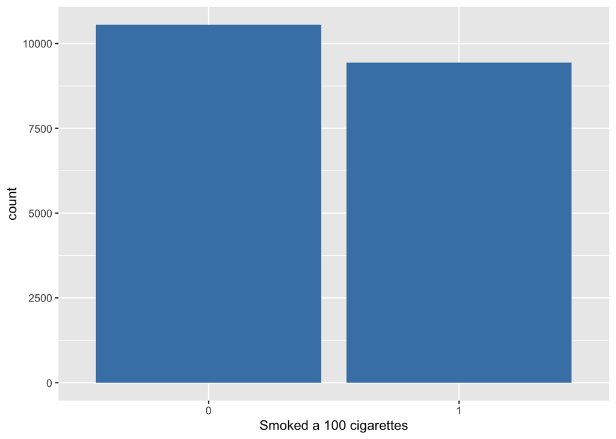

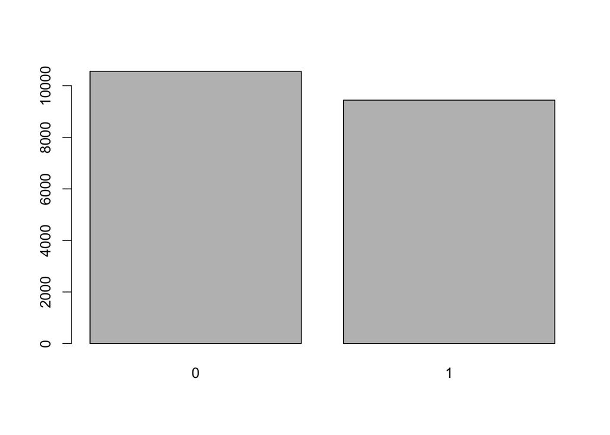

```r
# Load package
library(ggplot2)

# Use 'geom_bar' for barplots using ggplot
ggplot(cdc, aes(x=factor(smoke100)))+
  geom_bar(fill="steelblue") +
  labs(x = 'Smoked a 100 cigarettes')

# Alternatively, use 'barplot' in base R
smoke <- table(cdc$smoke100)
barplot(smoke)
```

The `table()` command can be used to tabulate any number of variables that you provide. For example, to examine which participants have smoked across each gender, we could use the following.

```r
table(cdc$gender,cdc$smoke100)
```

```
##
##        0    1
##   m 4547 5022
##   f 6012 4419
```

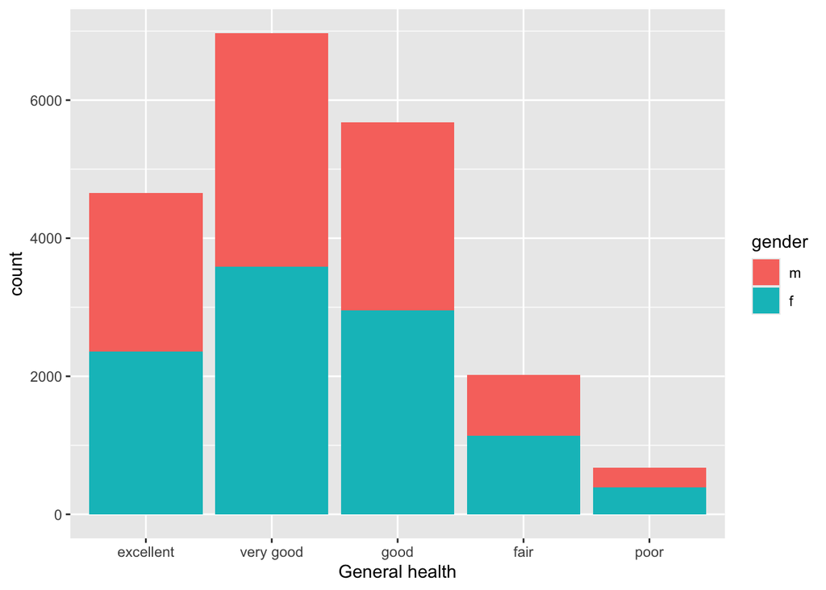

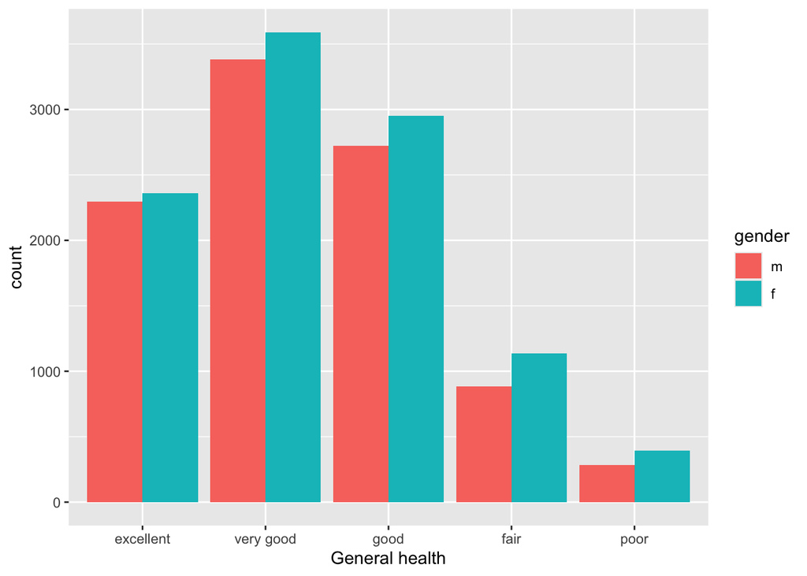

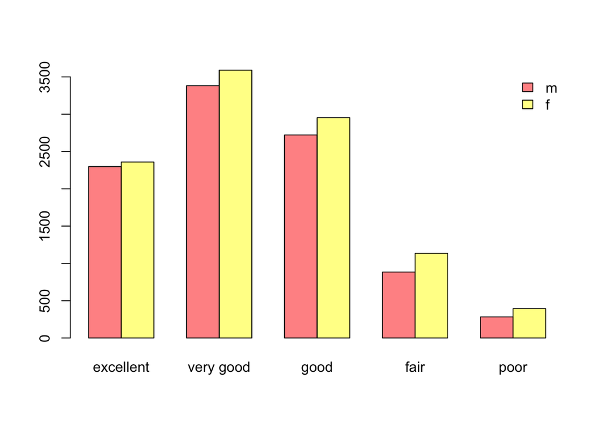

```r
# Stacked barplot
ggplot(data = cdc, aes(x = genhlth, fill = gender)) +
  geom_bar() +  labs(x = "General health") +
  theme(axis.text.x=element_text(angle = 0, hjust = 0.5))

# Side-by-side barplot
ggplot(data = cdc, aes(x = genhlth, fill = gender)) +
  geom_bar(position = "dodge") +  labs(x = "General health") +
  theme(axis.text.x=element_text(angle = 0, hjust = 0.5))

# Alternatively, , use 'barplot' in base R
# Note you need to provide the function with a table
#par(mfrow=c(1, 1), mar=c(3, 3, 1, 2))
barplot(table(cdc$gender,cdc$genhlth), beside=T, legend.text = TRUE,
        col=heat.colors(2, alpha=0.5),
        args.legend = list(x="topright",bty="n"))
```

## Interlude: How R thinks about data

We mentioned that R stores data in data frames, which you might think of as a type of spreadsheet. Each row is a different observation (a different respondent) and each column is a different variable. We can see the size of the data frame next to the object name in the workspace or we can type:

```r
dim(cdc)
```

```
## [1] 20000     9
```

Now, if we want to access a subset of the full data frame, we can use row-and-column notation. For example, to see the sixth variable of the 567$^{\textrm{th}}$ respondent, use the format

```r
cdc[567,6]
```

```
## [1] 160
```

which means we want the element of our data set that is in the 567$^{\textrm{th}}$ row (meaning the 567$^{\textrm{th}}$ person or observation) and the 6$^{\textrm{th}}$ column (in this case, weight). We know that `weight` is the 6$^{\textrm{th}}$ variable because it is the 6$^{\textrm{th}}$ entry in the list of variable names.

To see the weights for the first 10 respondents we can type

```r
cdc[1:10,6]
```

```
##  [1] 175 125 105 132 150 114 194 170 150 180
```

In this expression, we have asked just for rows in the range 1 through 10. R uses the ``:’’ to create a range of values, so 1:10 expands to 1, 2, 3, 4, 5, 6, 7, 8, 9, 10. You can see this by entering

```r
1:10
```

```
##  [1]  1  2  3  4  5  6  7  8  9 10
```

Finally, if we want all of the data for the first 10 respondents, type

```r
cdc[1:10,]
```

```
##      genhlth exerany hlthplan smoke100 height weight wtdesire age gender
## 1       good       0        1        0     70    175      175  77      m
## 2       good       0        1        1     64    125      115  33      f
## 3       good       1        1        1     60    105      105  49      f
## 4       good       1        1        0     66    132      124  42      f
## 5  very good       0        1        0     61    150      130  55      f
## 6  very good       1        1        0     64    114      114  55      f
## 7  very good       1        1        0     71    194      185  31      m
## 8  very good       0        1        0     67    170      160  45      m
## 9       good       0        1        1     65    150      130  27      f
## 10      good       1        1        0     70    180      170  44      m
```

By leaving out an index or a range (we didn’t type anything between the comma and the square bracket), we get all the columns. When starting out in R, this is a bit counterintuitive and perhaps even unexpected. As a rule, we omit the column number to see all columns in a data frame. Similarly, if we leave out an index or range for the rows, we would access all the observations, not just the 567$^{\textrm{th}}$, or rows 1 through 10. Try the following to see the weights for all 20,000 respondents fly by on your screen

```r
cdc[,6]
```

Recall that column 6 represents respondents’ weight, so the command above reported all of the weights in the data set. An alternative method to access the weight data is by referring to the name. Previously, we typed `names(cdc)` to see all the variables contained in the cdc data set. We can use any of the variable names to select items in our data set.

```r
cdc$weight
```

The dollar-sign tells R to look in data frame `cdc` for the column called `weight`. Since that’s a single vector, we can subset it with just a single index inside square brackets. We see the weight for the 567th respondent by typing

```r
cdc$weight[567]
```

```
## [1] 160
```

Similarly, for just the first 10 respondents

```r
cdc$weight[1:10]
```

```
##  [1] 175 125 105 132 150 114 194 170 150 180
```

The command above returns the same result as the `cdc[1:10, 6]` command. Both row-and-column notation and dollar-sign notation are widely used, which one you choose to use depends on your personal preference.

## A little more on subsetting

It’s often useful to extract all individuals (cases) in a data set that have specific characteristics. We accomplish this through `conditioning` commands. First, consider expressions like

```r
cdc$gender == "m"
```

or

```r
cdc$age > 30
```

These commands produce a series of `TRUE` and `FALSE` values. There is one value for each respondent, where `TRUE` indicates that the person was male (via the first command) or older than 30 (second command).

Suppose we want to extract just the data for the men in the sample, or just for those over 30. We can use the R function `subset()` to do that for us. For example, the command

```r
mdata <- subset(cdc, cdc$gender == "m")
```

will create a new data set called `mdata` that contains only the men from the `cdc` data set. In addition to finding it in your workspace alongside its dimensions, you can take a peek at the first several rows as usual

```r
head(mdata)
```

```
##      genhlth exerany hlthplan smoke100 height weight wtdesire age gender
## 1       good       0        1        0     70    175      175  77      m
## 7  very good       1        1        0     71    194      185  31      m
## 8  very good       0        1        0     67    170      160  45      m
## 10      good       1        1        0     70    180      170  44      m
## 11 excellent       1        1        1     69    186      175  46      m
## 12      fair       1        1        1     69    168      148  62      m
```

This new data set contains all the same variables but just under half the rows. It is also possible to tell R to keep only specific variables, which is a topic we’ll discuss in a future lab. For now, the important thing is that we can carve up the data based on values of one or more variables.

As an aside, you can use several of these conditions together with `&` and `|`. The `&` is read ``and’’ so that

```r
m_and_over30 <- subset(cdc, cdc$gender == "m" & cdc$age > 30)
head(m_and_over30)
```

```
##      genhlth exerany hlthplan smoke100 height weight wtdesire age gender
## 1       good       0        1        0     70    175      175  77      m
## 7  very good       1        1        0     71    194      185  31      m
## 8  very good       0        1        0     67    170      160  45      m
## 10      good       1        1        0     70    180      170  44      m
## 11 excellent       1        1        1     69    186      175  46      m
## 12      fair       1        1        1     69    168      148  62      m
```

will give you the data for men over the age of 30. The `|` character is read ``or’’ so that

```r
m_or_over30 <- subset(cdc, cdc$gender == "m" | cdc$age > 30)
head(m_or_over30)
```

```
##     genhlth exerany hlthplan smoke100 height weight wtdesire age gender
## 1      good       0        1        0     70    175      175  77      m
## 2      good       0        1        1     64    125      115  33      f
## 3      good       1        1        1     60    105      105  49      f
## 4      good       1        1        0     66    132      124  42      f
## 5 very good       0        1        0     61    150      130  55      f
## 6 very good       1        1        0     64    114      114  55      f
```

will take people who are men or over the age of 30 (why that’s an interesting group is hard to say, but right now the mechanics of this are the important thing). In principle, you may use as many `and'' and`or’’ clauses as you like when forming a subset.

**Exercise:** Create a new object called `under23_and_smoke` that contains all observations of respondents under the age of 23 that have smoked 100 cigarettes in their lifetime. Write the command you used to create the new object as the answer to this exercise.

## Quantitative data

With our subsetting tools in hand, we’ll now return to the task of the day: making basic summaries of the BRFSS questionaire. We’ve already looked at categorical data such as `smoke` and `gender` so now let’s turn our attention to quantitative data. Two common ways to visualize quantitative data are with box plots and histograms. We can construct a box plot for a single variable with the following command.

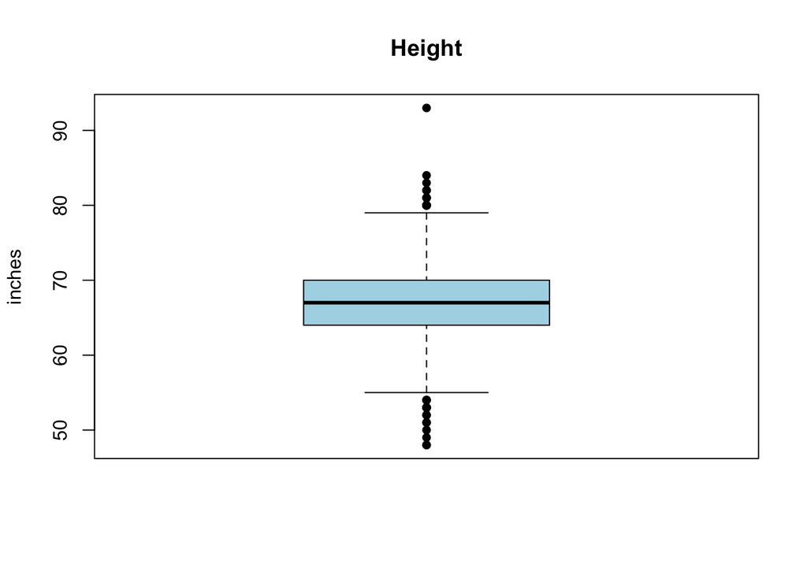

```r
# Base R command for single boxplots, no ggplot
# upper whisker = min(max(x), Q_3 + 1.5 * IQR)
# lower whisker = max(min(x), Q_1 – 1.5 * IQR)

boxplot(cdc$height, col= "lightblue", pch=16, main="Height", ylab="inches")
```

You can compare the locations of the components of the box by examining the summary statistics.

```r
summary(cdc$height)
```

```
##    Min. 1st Qu.  Median    Mean 3rd Qu.    Max.
##   48.00   64.00   67.00   67.18   70.00   93.00
```

Confirm that the median and upper and lower quartiles reported in the numerical summary match those in the graph. The purpose of a boxplot is to provide a thumbnail sketch of a variable for the purpose of comparing across several categories. So we can, for example, compare the heights of men and women with

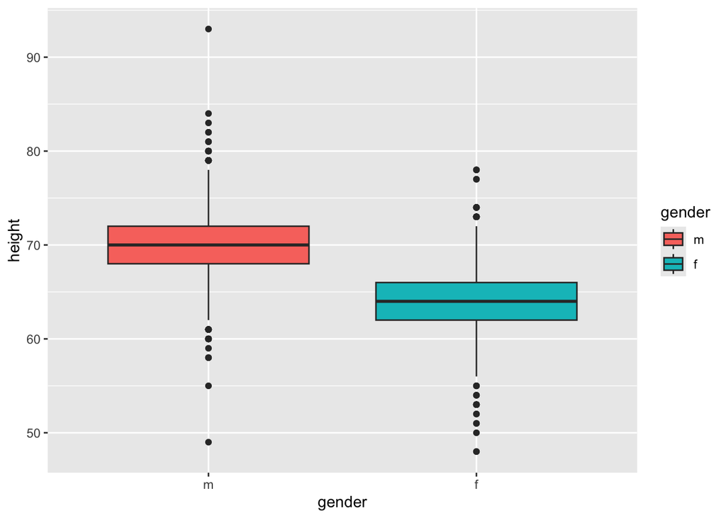

```r
ggplot(cdc, aes(x=gender, y=height, fill=gender)) +
  geom_boxplot()
```

Next let’s consider a new variable that doesn’t show up directly in this data set: Body Mass Index (BMI). BMI is a weight to height ratio and can be calculated as $BMI = \frac{weight~(lb)}{height~(in)^2} * 703$ where 703 is the approximate conversion factor to change units from metric (meters and kilograms) to imperial (inches and pounds).

The following two lines first make a new object called `bmi` and then creates box plots of these values, defining groups by the variable `cdc\$genhlth`.

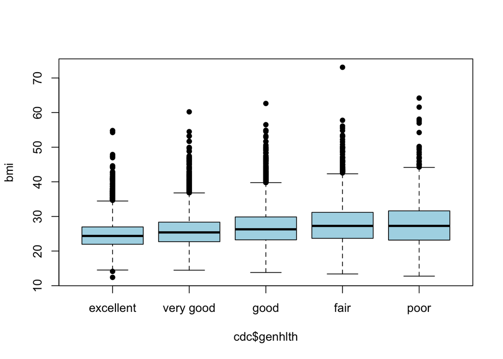

```r
# create new vector with bmi values
bmi <- (cdc$weight / cdc$height^2) * 703

# Base R code for boxplot by group, no ggplot
boxplot(bmi ~ cdc$genhlth, col="lightblue", pch=16)
```

To generate plots of `bmi` using `ggplot` we need to add the variable to the dataframe, `ggplot` only works with dataframes.

```r
# Load package dplyr, great for data mining
library("dplyr")
# Add column to cdc dataframe
cdc_bmi <- mutate(cdc, bmi = (cdc$weight / cdc$height^2) * 703)
head(cdc_bmi)
```

```
##     genhlth exerany hlthplan smoke100 height weight wtdesire age gender
## 1      good       0        1        0     70    175      175  77      m
## 2      good       0        1        1     64    125      115  33      f
## 3      good       1        1        1     60    105      105  49      f
## 4      good       1        1        0     66    132      124  42      f
## 5 very good       0        1        0     61    150      130  55      f
## 6 very good       1        1        0     64    114      114  55      f
##        bmi
## 1 25.10714
## 2 21.45386
## 3 20.50417
## 4 21.30303
## 5 28.33916
## 6 19.56592
```

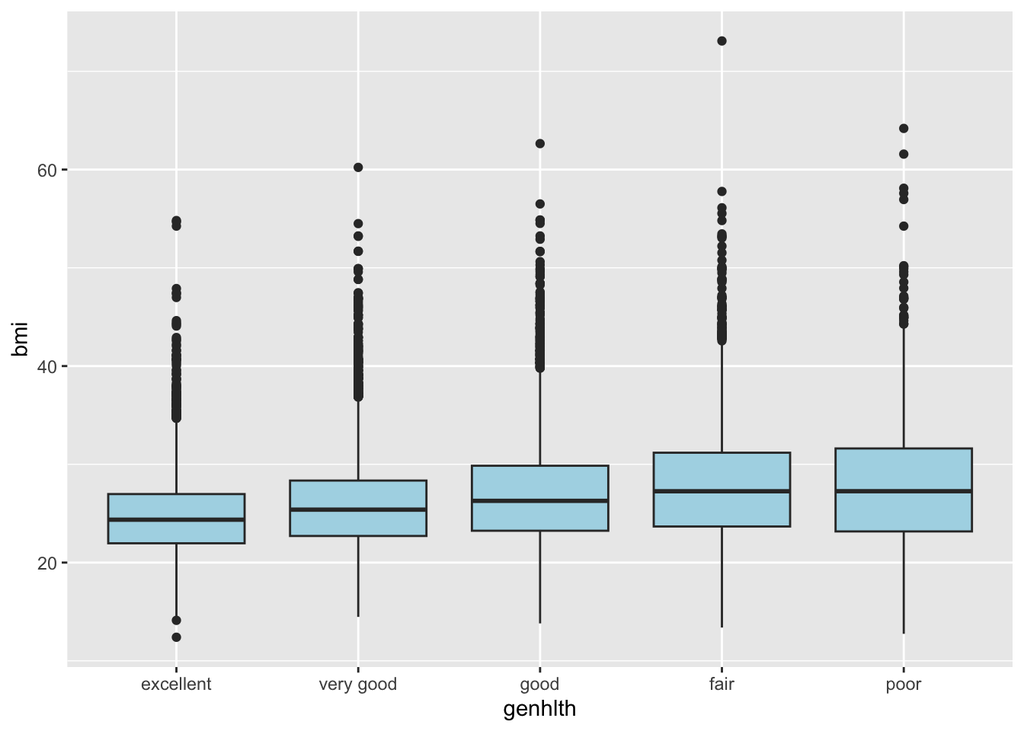

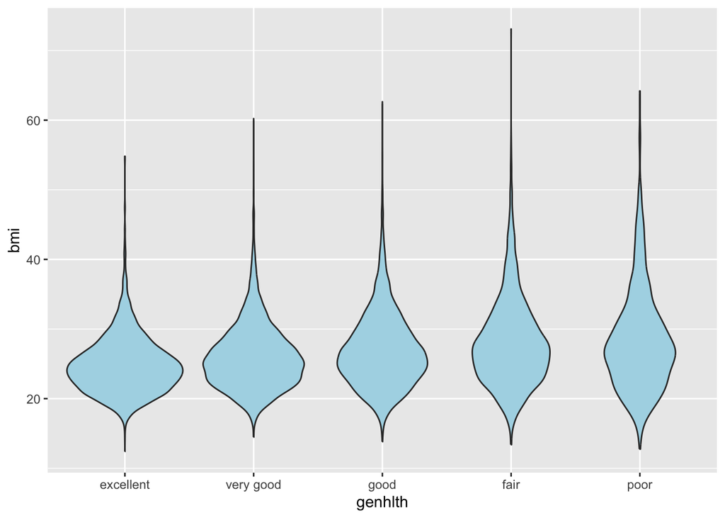

```r
ggplot(cdc, aes(x=genhlth, y=bmi)) +
  geom_boxplot(fill="lightblue")
ggplot(cdc, aes(x=genhlth, y=bmi)) +
  geom_violin(fill="lightblue")
```

Notice that the first line above is just some arithmetic, but it’s applied to all 20,000 numbers in the `cdc` data set. That is, for each of the 20,000 participants, we take their weight, divide by their height-squared and then multiply by 703. The result is 20,000 BMI values, one for each respondent. This is one reason why we like R: it lets us perform computations like this using very simple expressions.

We can also combine several categorical variables in a plot like this,

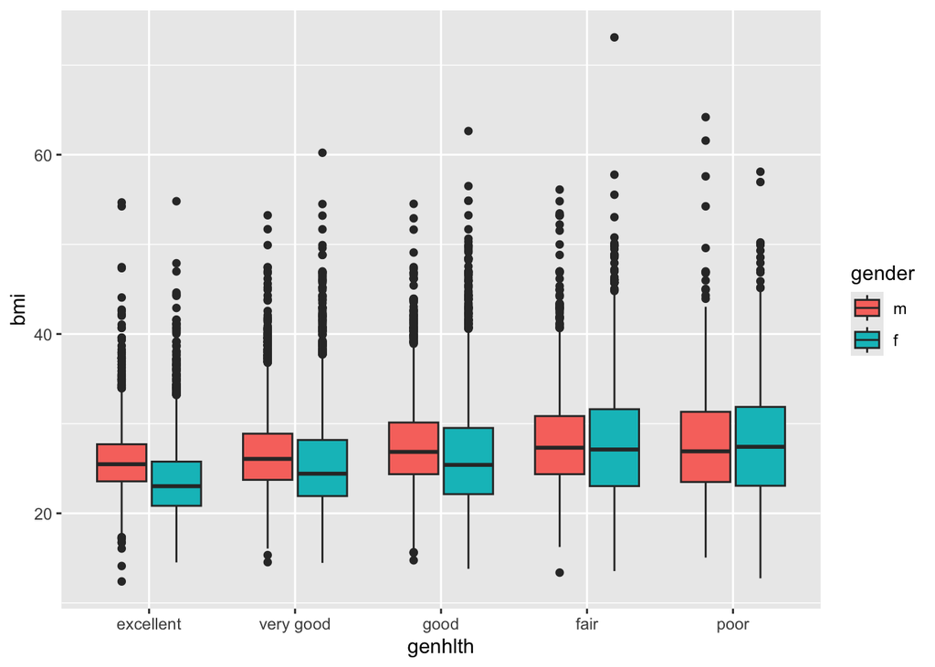

```r
ggplot(cdc, aes(x=genhlth, y=bmi, fill=gender)) +
  geom_boxplot()
```

**Exercise:** What does this box plot show? Do you see any differences between genders? Pick another categorical variable from the data set and see how it relates to BMI. List the variable you chose, why you might think it would have a relationship to BMI, and indicate what the figure seems to suggest.

Finally, let’s make some histograms. We can look at the histogram for the age of our respondents with the command

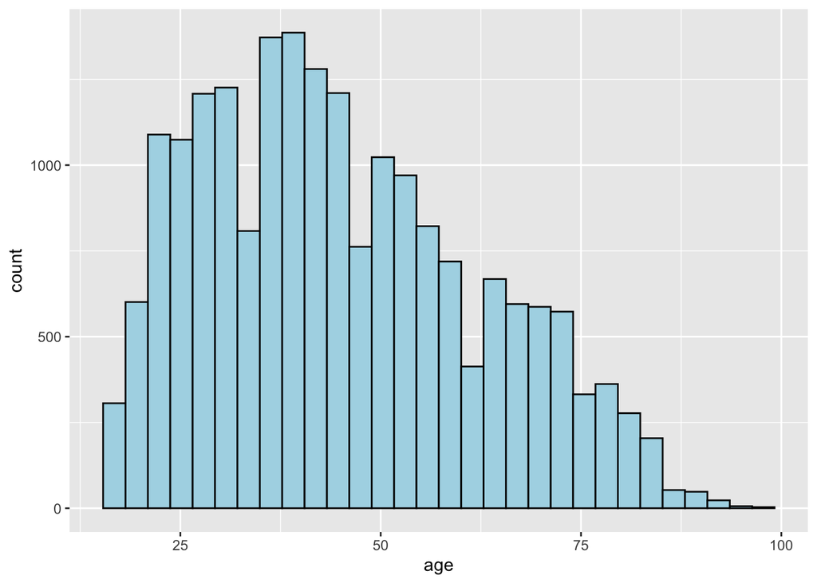

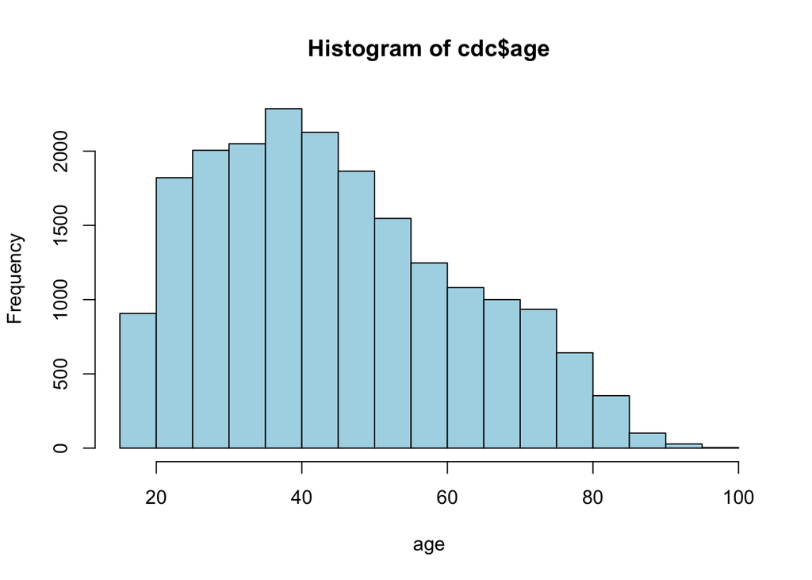

```r
ggplot(cdc, aes(x=age)) +
  geom_histogram(color="black", fill="lightblue")

# Base R command for histograms, no ggplot
hist(cdc$age, col="lightblue", xlab="age")
```

Histograms are generally a very good way to see the shape of a single distribution, but that shape can change depending on how the data is split between the different bins. The two histograms above have a different number of bins by default. You can control the number of bins by adding an argument to the command. In the next code, we make a histogram of `bmi` with 20 breaks.

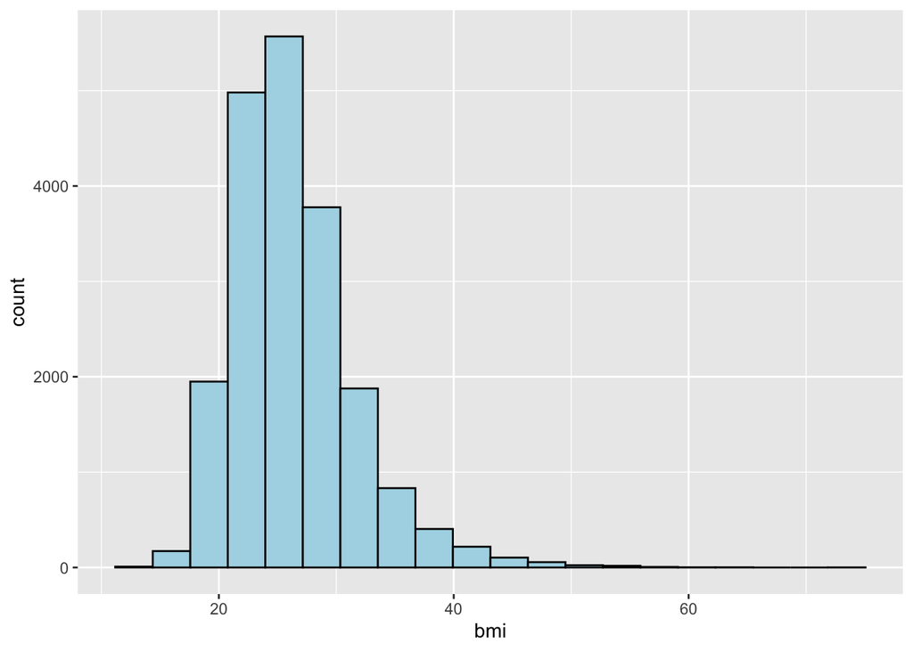

```r
ggplot(cdc, aes(x=bmi)) +
  geom_histogram(color="black", fill="lightblue", bins=20)
```

We can also see histograms for different levels of a categorical variable in the same plot.

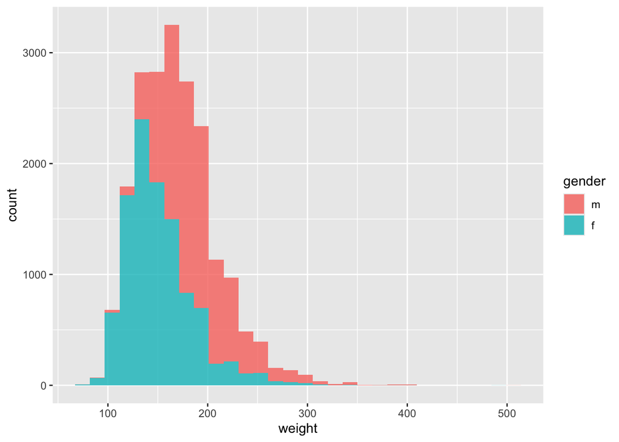

```r
ggplot(cdc, aes(x=weight, fill=gender)) +
  geom_histogram(alpha=0.8)
```

At this point, we’ve done a good first pass at analyzing the information in the BRFSS questionnaire. We’ve found an interesting association between smoking and gender, and we can say something about the relationship between people’s assessment of their general health and their own BMI. We’ve also picked up essential computing tools – summary statistics, subsetting, and plots – that will serve us well throughout this course.

## Practice

1. Make a scatterplot of weight versus desired weight. Describe the relationship between these two variables.
2. Let’s consider a new variable: the difference between desired weight (`wtdesire`) and current weight (`weight`). Create this new variable by subtracting the two columns in the data frame and assigning them to a new object called `wdiff`.
3. What type of data is `wdiff`? If an observation `wdiff` is 0, what does this mean about the person’s weight and desired weight. What if `whiff` is positive or negative?
4. Describe the shape of the distribution of `wdiff` include any plots you use. What does this tell us about how people feel about their current weight?
5. Using numerical summaries and a side-by-side box plot, determine if men tend to view their weight differently than women.
6. Now it’s time to get creative. Find the mean and standard deviation of `weight` and determine what proportion of the weights are within one standard deviation of the mean.

This is a modified version of a Lab product of OpenIntro that is released under a [Creative Commons Attribution-ShareAlike 3.0 Unported](http://creativecommons.org/licenses/by-sa/3.0). This lab was adapted for OpenIntro by Andrew Bray and Mine Çetinkaya-Rundel